# R Workshop: Exploratory Data Analysis

Sara Eftekhar Azam

2024-05

## Introduction

In this part of the workshop, we are going to use R language to analyze, filter, group, and plot data.

We are going to use tidyverse package.

## Loading packages

First, we have to install packages (if not already installed). The packages we are going to use are tidyverse, ggplot2, dplyr, and magrittr.

tidyverse: This is a collection of R packages designed for data science. It includes some datasets too.

ggplot2: This package is used for creating elegant and complex data visualizations.

dplyr: This package provides a set of functions for data manipulation tasks such as filtering, grouping, summarizing, and mutating data frames.

magrittr: This package provides the pipe operator %>%, which allows you to chain together multiple operations.

To install a package, use install.packages(“name of package”) in the console or terminal below. You only have to do this once.

install.packages(“tidyverse”) install.packages(“ggplot2”) install.packages(“dplyr”) install.packages(“magrittr”)

To run a cell, click on the run button. (echo = FALSE) prevents showing the output.

After installing the packages, we should include or import them to use them later:

## Loading data and initial exploring dataset

You can load data from file using: data <- read.csv(“data.csv”)

However, the packages we are using have many good datasets inside them. We can use them too. To see their available datasets, run the following chunk:

```r
data(package = "ggplot2")
```

I am going to use mpg dataset, but feel free to change the dataset and use some other dataset.

Let’s load our dataset:

```r
data(mpg)
```

```r
# View the first few rows of the dataset
head(mpg)
```

```
## # A tibble: 6 × 11
##   manufacturer model displ  year   cyl trans      drv     cty   hwy fl    class
##   <chr>        <chr> <dbl> <int> <int> <chr>      <chr> <int> <int> <chr> <chr>
## 1 audi         a4      1.8  1999     4 auto(l5)   f        18    29 p     compa…
## 2 audi         a4      1.8  1999     4 manual(m5) f        21    29 p     compa…
## 3 audi         a4      2    2008     4 manual(m6) f        20    31 p     compa…
## 4 audi         a4      2    2008     4 auto(av)   f        21    30 p     compa…
## 5 audi         a4      2.8  1999     6 auto(l5)   f        16    26 p     compa…
## 6 audi         a4      2.8  1999     6 manual(m5) f        18    26 p     compa…
```

Here is a short description of different columns in this dataset:

manufacturer: This column represents the manufacturer or company that produced the car. For example, “audi”, “chevrolet”, “ford”, etc. model: This column specifies the model name or identifier of the car. It usually refers to the specific make and model of the vehicle, such as “a4”, “corvette”, “mustang”, etc. displ: The “displ” column stands for engine displacement, which refers to the volume of space in the engine cylinders where combustion occurs. It’s typically measured in liters (L) or cubic inches (cu. in.). Engine displacement is an indicator of engine size and power. year: This column indicates the year the car was manufactured. cyl: The “cyl” column represents the number of cylinders in the engine. Cars can have different numbers of cylinders, such as 4-cylinder, 6-cylinder, or 8-cylinder engines. trans: This column specifies the type of transmission in the car, such as automatic or manual. It may also include additional details about the transmission system. drv: The “drv” column represents the type of drive train, which refers to how power is transmitted from the engine to the wheels. Common drive train types include front-wheel drive (fwd), rear-wheel drive (rwd), and four-wheel drive (4wd). cty: The “cty” column stands for city mileage, which represents the estimated fuel efficiency of the car in miles per gallon (mpg) when driving in city conditions. hwy: The “hwy” column represents highway mileage, which indicates the estimated fuel efficiency of the car in miles per gallon (mpg) when driving on the highway. fl: This column indicates the fuel type used by the car, such as regular gasoline (r), premium gasoline (p), or diesel (d). class: The “class” column specifies the class or category of the car, such as compact, midsize, or SUV (sport utility vehicle).

```r
# Display the structure of the dataset
str(mpg)
```

```
## tibble [234 × 11] (S3: tbl_df/tbl/data.frame)
##  $ manufacturer: chr [1:234] "audi" "audi" "audi" "audi" ...
##  $ model       : chr [1:234] "a4" "a4" "a4" "a4" ...
##  $ displ       : num [1:234] 1.8 1.8 2 2 2.8 2.8 3.1 1.8 1.8 2 ...
##  $ year        : int [1:234] 1999 1999 2008 2008 1999 1999 2008 1999 1999 2008 ...
##  $ cyl         : int [1:234] 4 4 4 4 6 6 6 4 4 4 ...
##  $ trans       : chr [1:234] "auto(l5)" "manual(m5)" "manual(m6)" "auto(av)" ...
##  $ drv         : chr [1:234] "f" "f" "f" "f" ...
##  $ cty         : int [1:234] 18 21 20 21 16 18 18 18 16 20 ...
##  $ hwy         : int [1:234] 29 29 31 30 26 26 27 26 25 28 ...
##  $ fl          : chr [1:234] "p" "p" "p" "p" ...
##  $ class       : chr [1:234] "compact" "compact" "compact" "compact" ...
```

```r
# Summary statistics for numerical variables
summary(mpg)
```

```
##  manufacturer          model               displ            year
##  Length:234         Length:234         Min.   :1.600   Min.   :1999
##  Class :character   Class :character   1st Qu.:2.400   1st Qu.:1999
##  Mode  :character   Mode  :character   Median :3.300   Median :2004
##                                        Mean   :3.472   Mean   :2004
##                                        3rd Qu.:4.600   3rd Qu.:2008
##                                        Max.   :7.000   Max.   :2008
##       cyl           trans               drv                 cty
##  Min.   :4.000   Length:234         Length:234         Min.   : 9.00
##  1st Qu.:4.000   Class :character   Class :character   1st Qu.:14.00
##  Median :6.000   Mode  :character   Mode  :character   Median :17.00
##  Mean   :5.889                                         Mean   :16.86
##  3rd Qu.:8.000                                         3rd Qu.:19.00
##  Max.   :8.000                                         Max.   :35.00
##       hwy             fl               class
##  Min.   :12.00   Length:234         Length:234
##  1st Qu.:18.00   Class :character   Class :character
##  Median :24.00   Mode  :character   Mode  :character
##  Mean   :23.44
##  3rd Qu.:27.00
##  Max.   :44.00
```

We can get unique values of a columns.

```r
# Get unique manufacturers using unique() function
#unique_manufacturers <- unique(mpg$manufacturer)
unique_manufacturers <- unique(mpg[["manufacturer"]])

# Print unique manufacturers
print(unique_manufacturers)
```

```
##  [1] "audi"       "chevrolet"  "dodge"      "ford"       "honda"
##  [6] "hyundai"    "jeep"       "land rover" "lincoln"    "mercury"
## [11] "nissan"     "pontiac"    "subaru"     "toyota"     "volkswagen"
```

## Group, filter, and plot data

Grouping in R is like using GROUP BY in SQL. Filtering in R is like adding conditions with WHERE in SQL. Plotting is rather simple and intuitive.

Let’s visualize the city and highway mileage (mile per gallon of fuel). The ggplot library acts in an additive way. You can add more and amore to the figure. Task: plot city vs highway mileage. Show engine size and vehicle class as size and color.

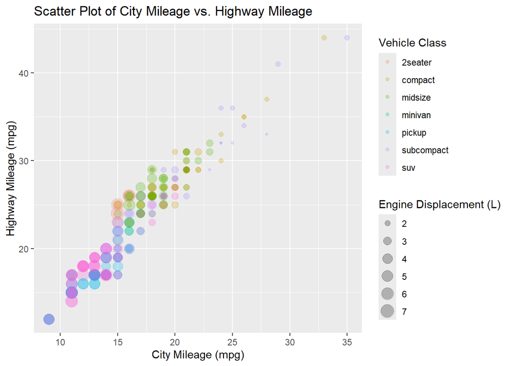

```r
ggplot(mpg, aes(x = cty, y = hwy, color = class, size = displ)) +
  geom_point(alpha = 0.25) +  # Add points for each data point with transparency
  scale_color_discrete(name = "Vehicle Class") +  # Custom color legend title
  scale_size_continuous(name = "Engine Displacement (L)") +  # Custom size legend title
  labs(x = "City Mileage (mpg)", y = "Highway Mileage (mpg)") +  # Labels for x and y axes
  ggtitle("Scatter Plot of City Mileage vs. Highway Mileage")  # Title for the plot
```

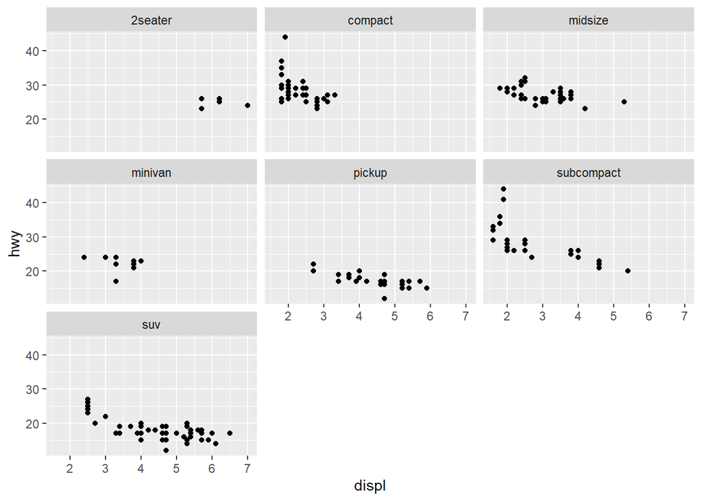

```r
ggplot(data = mpg) +
  geom_point(mapping = aes(x = displ, y = hwy)) +
  facet_wrap(~ class)
```

We are going to learn how to do these by doing some example tasks.

### Task 1:

Compare the average city and highway mileage for different car manufacturers. Only consider car that were made after 1999. Plot bar chart to show the results.

First, we see how this can be done without pipe %>% operator.

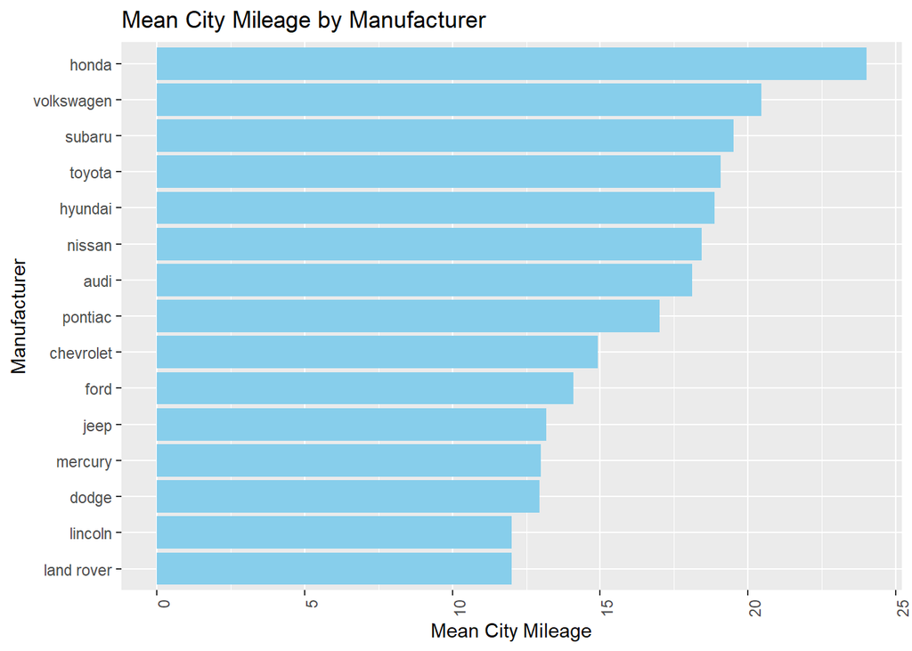

```r
t1_filtered_mpg <- filter(mpg, year > 1999)
t1_grouped_mpg <- group_by(t1_filtered_mpg, manufacturer)
t1_summarized_mpg <- summarise(t1_grouped_mpg, mean_city_mileage = mean(cty), mean_highway_mileage = mean(hwy))

ggplot(t1_summarized_mpg, aes(x = reorder(manufacturer, mean_city_mileage), y = mean_city_mileage)) +
  geom_bar(stat = "identity", fill = "skyblue", aes(fill = manufacturer)) +
  labs(x = "Manufacturer", y = "Mean City Mileage") +
  ggtitle("Mean City Mileage by Manufacturer") +
  theme(axis.text.x = element_text(angle = 90, hjust = 1)) +
  coord_flip()
```

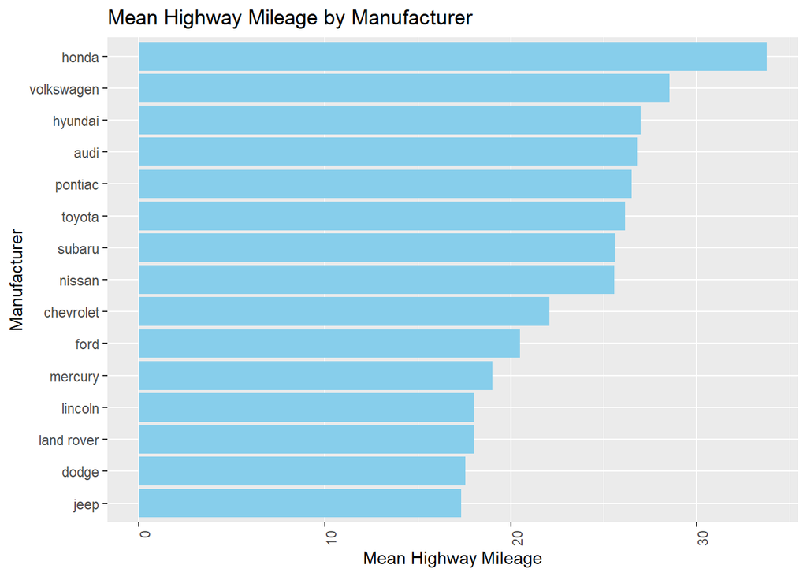

```r
ggplot(t1_summarized_mpg, aes(x = reorder(manufacturer, mean_highway_mileage), y = mean_highway_mileage)) +
  geom_bar(stat = "identity", fill = "skyblue", aes(fill = manufacturer)) +
  labs(x = "Manufacturer", y = "Mean Highway Mileage") +
  ggtitle("Mean Highway Mileage by Manufacturer") +
  theme(axis.text.x = element_text(angle = 90, hjust = 1)) +
  coord_flip()
```

Now, let’s do this with pip %>% operator. This is much shorter:

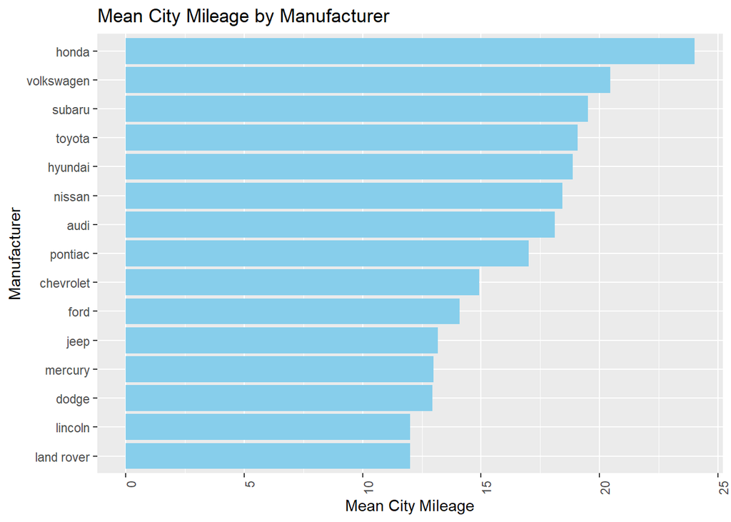

```r
t1_summarized_mpg_with_pipe <- mpg %>%
  filter(year > 1999) %>%
  group_by(manufacturer) %>%
  summarise(mean_city_mileage = mean(cty), mean_highway_mileage = mean(hwy))

ggplot(t1_summarized_mpg_with_pipe, aes(x = reorder(manufacturer, mean_city_mileage), y = mean_city_mileage)) +
  geom_bar(stat = "identity", fill = "skyblue", aes(fill = manufacturer)) +
  labs(x = "Manufacturer", y = "Mean City Mileage") +
  ggtitle("Mean City Mileage by Manufacturer") +
  theme(axis.text.x = element_text(angle = 90, hjust = 1)) +
  coord_flip()
```

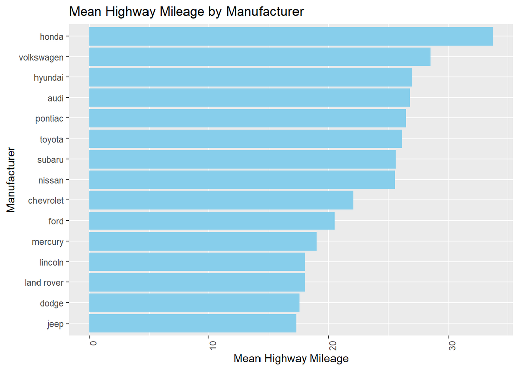

```r
ggplot(t1_summarized_mpg_with_pipe, aes(x = reorder(manufacturer, mean_highway_mileage), y = mean_highway_mileage)) +
  geom_bar(stat = "identity", fill = "skyblue", aes(fill = manufacturer)) +
  labs(x = "Manufacturer", y = "Mean Highway Mileage") +
  ggtitle("Mean Highway Mileage by Manufacturer") +
  theme(axis.text.x = element_text(angle = 90, hjust = 1)) +
  coord_flip()
```

### Task 2:

Plot city and highway mileage (mile per gallon) in a scatter plot for cars made between 1995 and 2005. Add a smooth line.

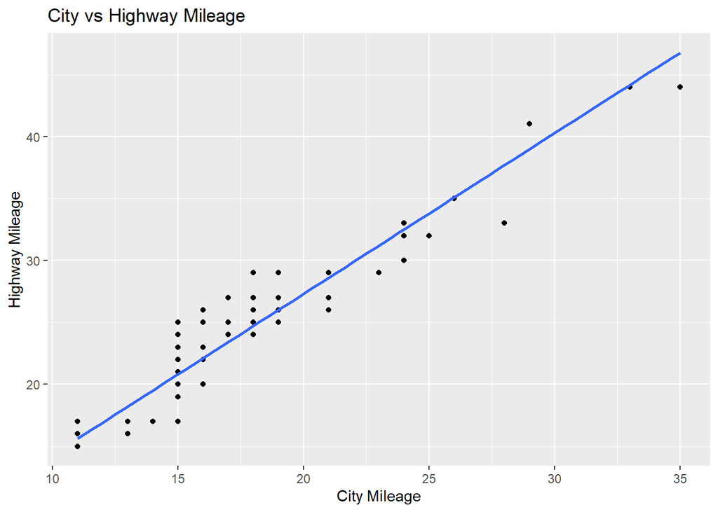

```r
task2_filtered_mpg = mpg %>% filter(year >= 1995 & year <= 2005)
ggplot(task2_filtered_mpg, aes(x = cty, y = hwy)) +
  geom_point(alpha = 1) +  # Add points
  geom_smooth(method = "lm", se = FALSE) +  # Add linear regression line with or without confidence interval
  labs(x = "City Mileage", y = "Highway Mileage") +
  ggtitle("City vs Highway Mileage")
```

### Task 3:

Use your imagination and come up with some way to filter, group, summarize, and plot data that is interesting.